# L3

# Search Problems

## Uniform Cost Search

- Type of uninformed search
- Explores in all directions, so it isn’t optimal

## Informed Search

- Heuristic ≔ a function that estimates how close a state is to a goal
  - designed for a particular search problem
  - Takes in a state and outputs a guess for how close you are to the goal
- Manhattan distance ≔ distance from a point making only one 90º turn
  - Possible heuristic

## Greedy Search

- Uninformed? search alg
- Fringe based algorithm
- Expand the node that *seems* closest with respect to some heuristic
- Not always optimal
- Somewhat like DFS because it explores a full path at a time

### Optimality

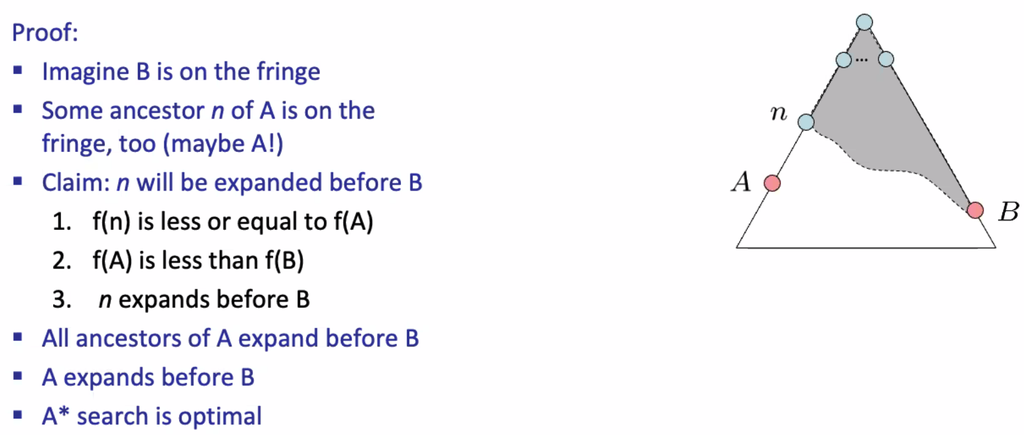

**Proof**: If $A$ is an optimal goal where $\{A,B\}\in\mathrm{goals}$, $A$ must be popped off the fringe before $B$ - Claim: $B\in\mathrm{fringe{}\implies}\exists\;{\text{Ancestor of A}\in\mathrm{fringe}}$ - Argument: $\text{Ancestor of A}$ will be popped off before $B$ - Known:
$$\begin{array}{c}
n\in{\mathrm{ancestors}_{A}\implies}f(n)\leq{f(A)} \\
B\in{\mathrm{goals}_{\mathrm{suboptimal}}{}\implies}f(A)<f(B)
\end{array}$$
The heuristic is admissible, so it must be an underestimate ⟹ $h(A)=h(B)=0$ ∴ $\{f(A)=g(A),f(B)=g(B)\}$

Given that $B$ is suboptimal, we know the path cost to A < the path cost to B: $g(A)<g(B)$

∴$f(n)\leq{f(A)}<f(B)$ so $n$ must be expanded before $B$ ⟹ all ancestors of $A$ are expanded before $B$ ∴ A* is optimal.

## Heuristics

- Two types:
  1. Optimistic
  2. Pessimistic
- Admissible (optimistic) iff $\left.{0\leq}h(n{)\leq}h^{*}(n)\right\vert_{h^{*}(n)\,\coloneqq\,\text{true cost to the nearest goal}}$

### Pessimistic (not admissible)

- Regardless of $h(n)$, consider $g(n)$ as more important
- **Breaks optimality** by trapping good plans on the fringe
- We thought the plan was bad, but it ended up being a good plan